# Sleep and Reaction

Livio Finos

# Import data

```r
#install.packages("lme4")
data("sleepstudy", package="lme4")
summary(sleepstudy)
```

```
##     Reaction          Days        Subject
##  Min.   :194.3   Min.   :0.0   308    : 10
##  1st Qu.:255.4   1st Qu.:2.0   309    : 10
##  Median :288.7   Median :4.5   310    : 10
##  Mean   :298.5   Mean   :4.5   330    : 10
##  3rd Qu.:336.8   3rd Qu.:7.0   331    : 10
##  Max.   :466.4   Max.   :9.0   332    : 10
##                                (Other):120
```

```r
library(lmerTest)
```

# First analysis (wrong)

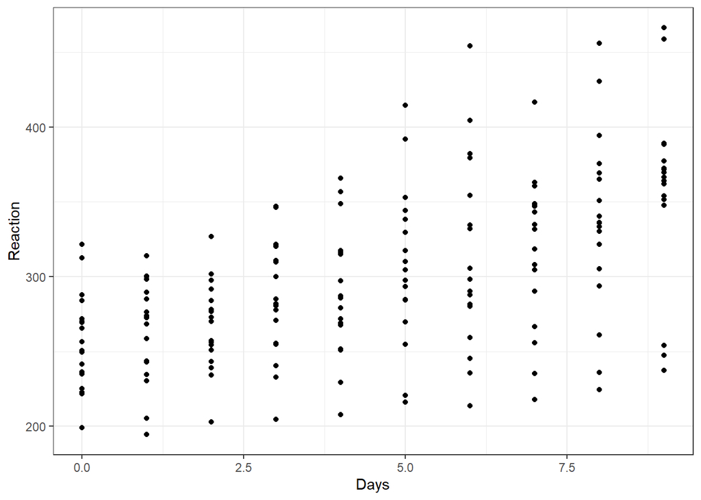

```r
library(ggplot2)
p=ggplot(sleepstudy, aes(x = Days, y = Reaction)) + geom_point() + theme_bw()

p
```

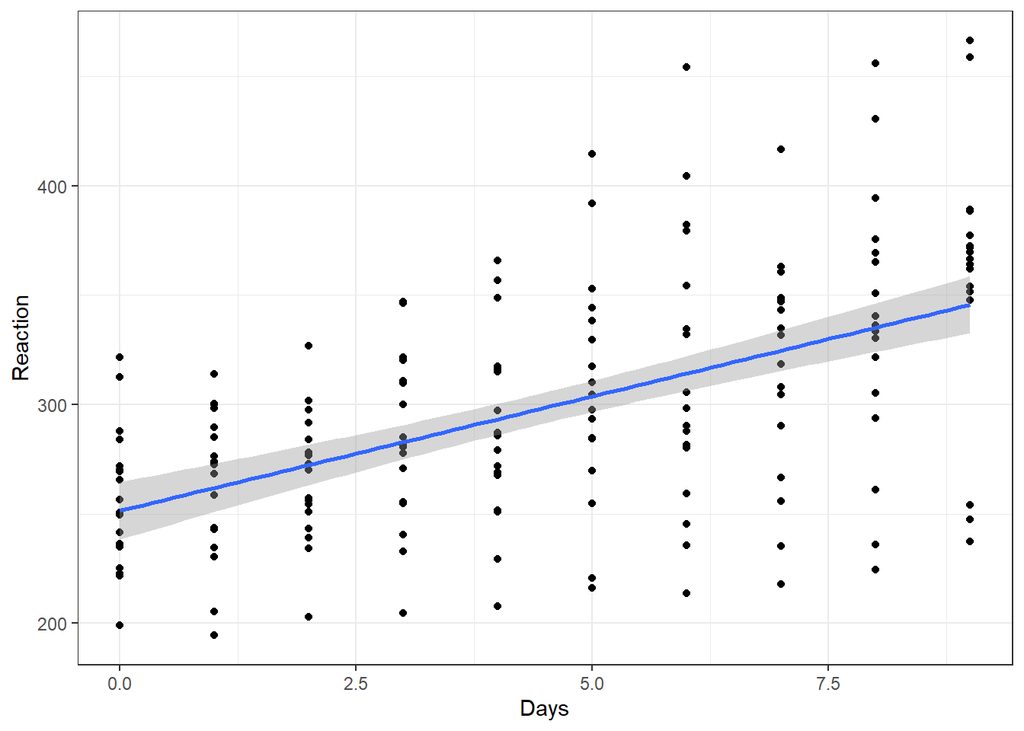

```r
p+geom_smooth(method=lm)
```

```r
mod <- lm(Reaction ~ Subject + Days, sleepstudy)
summary(mod)
```

```
##
## Call:
## lm(formula = Reaction ~ Subject + Days, data = sleepstudy)
##
## Residuals:
##      Min       1Q   Median       3Q      Max
## -100.540  -16.389   -0.341   15.215  131.159
##
## Coefficients:
##              Estimate Std. Error t value Pr(>|t|)
## (Intercept)  295.0310    10.4471  28.240  < 2e-16 ***
## Subject309  -126.9008    13.8597  -9.156 2.35e-16 ***
## Subject310  -111.1326    13.8597  -8.018 2.07e-13 ***
## Subject330   -38.9124    13.8597  -2.808 0.005609 **
## Subject331   -32.6978    13.8597  -2.359 0.019514 *
## Subject332   -34.8318    13.8597  -2.513 0.012949 *
## Subject333   -25.9755    13.8597  -1.874 0.062718 .
## Subject334   -46.8318    13.8597  -3.379 0.000913 ***
## Subject335   -92.0638    13.8597  -6.643 4.51e-10 ***
## Subject337    33.5872    13.8597   2.423 0.016486 *
## Subject349   -66.2994    13.8597  -4.784 3.87e-06 ***
## Subject350   -28.5311    13.8597  -2.059 0.041147 *
## Subject351   -52.0361    13.8597  -3.754 0.000242 ***
## Subject352    -4.7123    13.8597  -0.340 0.734300
## Subject369   -36.0992    13.8597  -2.605 0.010059 *
## Subject370   -50.4321    13.8597  -3.639 0.000369 ***
## Subject371   -47.1498    13.8597  -3.402 0.000844 ***
## Subject372   -24.2477    13.8597  -1.750 0.082108 .
## Days          10.4673     0.8042  13.015  < 2e-16 ***
## ---
## Signif. codes:  0 '***' 0.001 '**' 0.01 '*' 0.05 '.' 0.1 ' ' 1
##
## Residual standard error: 30.99 on 161 degrees of freedom
## Multiple R-squared:  0.7277, Adjusted R-squared:  0.6973
## F-statistic: 23.91 on 18 and 161 DF,  p-value: < 2.2e-16
```

# Second analysis: Repeated measures ANOVA

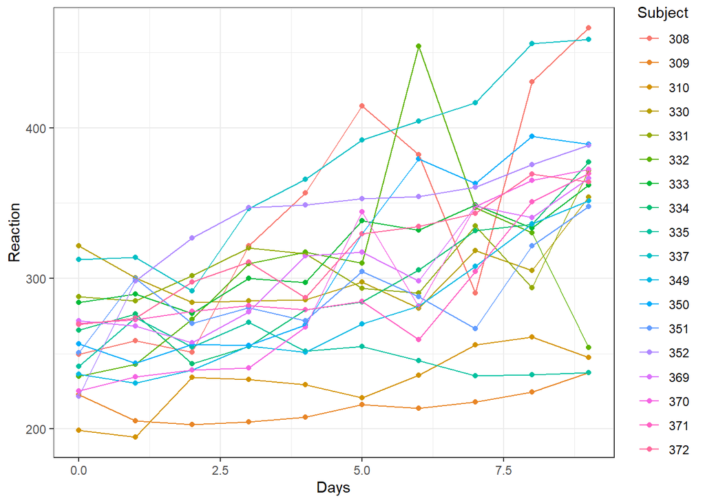

```r
p=ggplot(sleepstudy, aes(x = Days, y = Reaction, colour = Subject, group = Subject)) + geom_point()  +geom_line(aes(x = Days, y = Reaction, colour = Subject, group = Subject))
p+ theme_bw()
```

```r
# The standard way
mod=aov(Reaction ~ Days + Error(Subject/(Days)),data=sleepstudy)
summary(mod)
```

```
##
## Error: Subject
##           Df Sum Sq Mean Sq F value Pr(>F)
## Residuals 17 250618   14742
##
## Error: Subject:Days
##           Df Sum Sq Mean Sq F value   Pr(>F)
## Days       1 162703  162703   45.85 3.26e-06 ***
## Residuals 17  60322    3548
## ---
## Signif. codes:  0 '***' 0.001 '**' 0.01 '*' 0.05 '.' 0.1 ' ' 1
##
## Error: Within
##            Df Sum Sq Mean Sq F value Pr(>F)
## Residuals 144  94312   654.9
```

A better output and slightly more compleate analysis (Sphericity Corrections):

```r
library(ez)
mod=ezANOVA(dv=Reaction, wid=Subject, within=.(Days),data=sleepstudy,type=3)
print(mod)
```

```
## $ANOVA
##   Effect DFn DFd        F            p p<.05       ges
## 1   Days   1  17 45.85301 3.263788e-06     * 0.7295277
```

## Sphericity

Sphericity is an assumption about the structure of the covariance matrix in a repeated measures design. It is not an issue in this example, but it is relevant when more than two conditions are measured within subject and compared. Assume, for example that three conditions are compared: `Condition A`, `Condition B` and `Condition C`.

Before we describe Sphericity, let’s consider a simpler (but more strict) condition.

**Compound symmetry**

Compound symmetry holds true when the variances within conditions are equal (this is the same as the homogeneity of variance assumption in between-group designs) but also when the covariances between pairs of conditions are roughly equal. As such, we assume that the variation within experimental conditions is fairly similar and that no two conditions are any more dependent than any other two.

Provided the observed covariances are roughly equal in our samples (and the variances are OK too) we can be pretty confident that compound symmetry is not violated.

Compound symmetry is met when the correlation between `Condition A` and `Condition B` is equal to the correlation between `Condition A` and `Condition C` and between `Condition B` and `Condition C` (and all pairwise comparisons, in general). But a more direct way to think about compound symmetry is to say that it requires that all subjects in each group change in the same way over trials. In other words the slopes of the lines regressing the dependent variable on time are the same for all subjects. Put that way it is easy to see that compound symmetry can really be an unrealistic assumption.

**Sphericity**

Although compound symmetry has been shown to be a sufficient condition for conducting ANOVA on repeated measures data, it is not a necessary condition. Sphericity is a less restrictive form of compound symmetry. Sphericity refers to the equality of variances of the differences between treatment levels. If you were to take each pair of treatment levels, and calculate the differences between each pair of scores it is necessary that these differences have equal variances.

We can check sphericity assumption using the covariance matrix, but it turns out to be fairly laborious. Remember that variance of differences can be computed as:
$$Var(x-y)=S^2_{x-y} = S^2_x +S^2_y -
2S_{xy}$$

Further reading: https://en.wikipedia.org/wiki/Mauchly%27s_sphericity_test

This is often an unrealistic assumption in EEG data (spatial location of channel relates to correlation between measures)

### (Further) Limitations of Repeated Measures ANOVA

- (Design and) Data must be balanced
- Repeated Measures Anova doesn’t allow for missing data
- It only handle factors, no quantitative variables

Mixed model is a more flexible approach.

# Third Analysis: Mixed model with random

**Random intercept and slope**

```r
library(lmerTest)
mod <- lmer(Reaction ~ 1+Days + (1 + Days| Subject), data=sleepstudy)
summary(mod)
```

```
## Linear mixed model fit by REML. t-tests use Satterthwaite's method [
## lmerModLmerTest]
## Formula: Reaction ~ 1 + Days + (1 + Days | Subject)
##    Data: sleepstudy
##
## REML criterion at convergence: 1743.6
##
## Scaled residuals:
##     Min      1Q  Median      3Q     Max
## -3.9536 -0.4634  0.0231  0.4634  5.1793
##
## Random effects:
##  Groups   Name        Variance Std.Dev. Corr
##  Subject  (Intercept) 612.10   24.741
##           Days         35.07    5.922   0.07
##  Residual             654.94   25.592
## Number of obs: 180, groups:  Subject, 18
##
## Fixed effects:
##             Estimate Std. Error      df t value Pr(>|t|)
## (Intercept)  251.405      6.825  17.000  36.838  < 2e-16 ***
## Days          10.467      1.546  17.000   6.771 3.26e-06 ***
## ---
## Signif. codes:  0 '***' 0.001 '**' 0.01 '*' 0.05 '.' 0.1 ' ' 1
##
## Correlation of Fixed Effects:
##      (Intr)
## Days -0.138
```

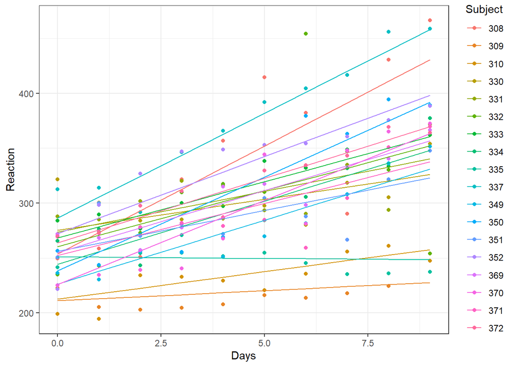

```r
sleepstudy$predicted=predict(mod)
library(ggplot2)
p=ggplot(sleepstudy, aes(x = Days, y = Reaction, colour = Subject, group = Subject)) + geom_point() + geom_line(aes(x = Days, y = predicted, colour = Subject, group = Subject))
p+ theme_bw()
```

What if we set only the Intercept as random component?

**Random intercept only**

```r
library(lmerTest)
mod <- lmer(Reaction ~ 1 + Days + (1 | Subject), data=sleepstudy)
summary(mod)
```

```
## Linear mixed model fit by REML. t-tests use Satterthwaite's method [
## lmerModLmerTest]
## Formula: Reaction ~ 1 + Days + (1 | Subject)
##    Data: sleepstudy
##
## REML criterion at convergence: 1786.5
##
## Scaled residuals:
##     Min      1Q  Median      3Q     Max
## -3.2257 -0.5529  0.0109  0.5188  4.2506
##
## Random effects:
##  Groups   Name        Variance Std.Dev.
##  Subject  (Intercept) 1378.2   37.12
##  Residual              960.5   30.99
## Number of obs: 180, groups:  Subject, 18
##
## Fixed effects:
##             Estimate Std. Error       df t value Pr(>|t|)
## (Intercept) 251.4051     9.7467  22.8102   25.79   <2e-16 ***
## Days         10.4673     0.8042 161.0000   13.02   <2e-16 ***
## ---
## Signif. codes:  0 '***' 0.001 '**' 0.01 '*' 0.05 '.' 0.1 ' ' 1
##
## Correlation of Fixed Effects:
##      (Intr)
## Days -0.371
```

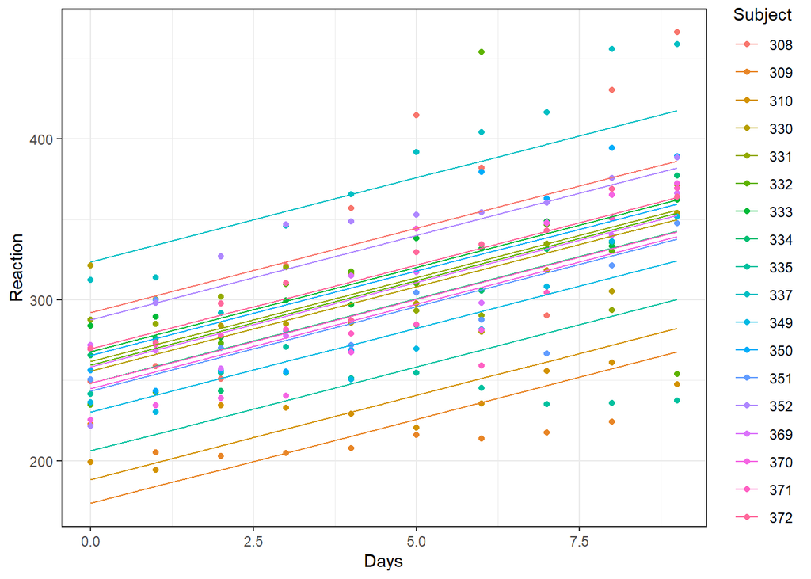

```r
sleepstudy$predicted=predict(mod)
library(ggplot2)
p=ggplot(sleepstudy, aes(x = Days, y = Reaction, colour = Subject, group = Subject)) + geom_point()  +geom_line(aes(x = Days, y = predicted, colour = Subject, group = Subject))
p+ theme_bw()
```

Is this model adequate? Does it adequately fit your data?

REMARKS:

- Mixed models require careful attention in defining random effects; for example, if we do not also include a random slope coefficient, we implicitly make the same assumptions about the sphericity of the repeated measures. There is still a lively debate today about the most appropriate way to define the random component structure in mixed models, see for example Barr et al. (2013) and Bates et al. (2015) [Barr, D. J., Levy, R., Scheepers, C., & Tily, H. J. (2013). Random effects structure for confirmatory hypothesis testing: Keep it maximal. Journal of memory and language, 68(3), 255-278. Bates, D., Kliegl, R., Vasishth, S., & Baayen, H. (2015). Parsimonious mixed models. arXiv preprint arXiv:1506.04967].
- Regarding the lines estimated with mixed models: they are similar but not identical to those we obtain if we estimate a line for each subject; in mixed models, we impose that the coefficients come from the same (normally distributed) population, and this implies that the estimates are (a bit) biased.

# Fourth analysis: Random Coefficient Analysis (= Summary Statistics = Second-level/Group-level Analisys)

## Summary statistics, one for each subject

```r
library(tidyverse)
dati1lev=sleepstudy %>%
  group_by(Subject) %>%
  summarize(Slope=(coefficients(lm(Reaction ~ Days))[2]))

head(dati1lev)
```

```
## # A tibble: 6 × 2
##   Subject Slope
##   <fct>   <dbl>
## 1 308     21.8
## 2 309      2.26
## 3 310      6.11
## 4 330      3.01
## 5 331      5.27
## 6 332      9.57
```

```r
mean(dati1lev$Slope)
```

```
## [1] 10.46729
```

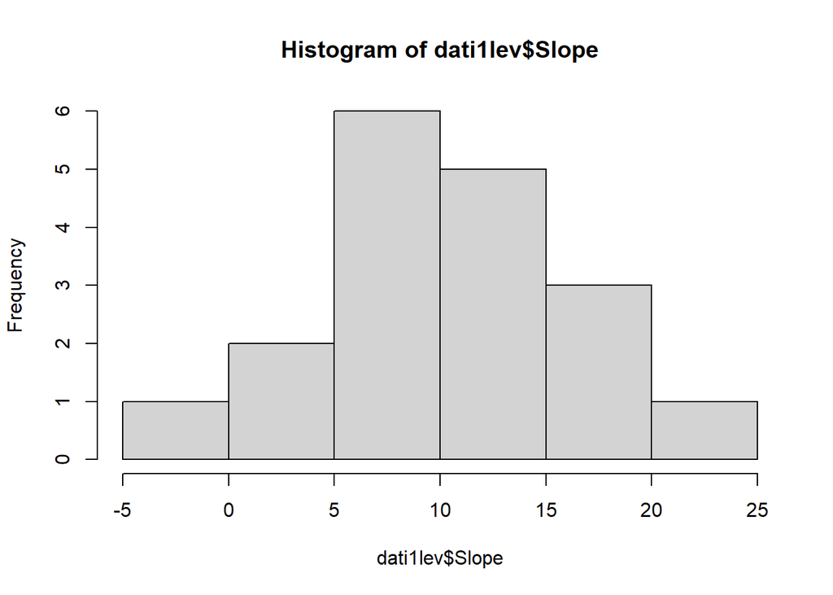

```r
hist(dati1lev$Slope)
```

## Parametric Analysis

If we are interested in testing if the sleep deprivation is associated with larger reaction times, we can simply test if the average of the slopes is equal to 0. This can be donw with a simple one-sample t.test.

```r
t.test(dati1lev$Slope)
```

```
##
##  One Sample t-test
##
## data:  dati1lev$Slope
## t = 6.7715, df = 17, p-value = 3.264e-06
## alternative hypothesis: true mean is not equal to 0
## 95 percent confidence interval:
##   7.205956 13.728615
## sample estimates:
## mean of x
##  10.46729
```

What are the assumptions that are done in this approach?

1. Independence of observations (= subjects in this method): OK
2. Homoscedasticity (= same variance for each observation/subject). It implies balanced design and same variability of the measures among all subjects. OK? Always OK?
3. Normality, but with an adequate number of observations, we can invoke the Central Limit Theorem.

## Working with permutations (Resampling-based)

The lack of assumption 2 can’t be (easily) solved via parametric approach. Let’s consider a nonparametric permutation approach.

The simple code one can use is:

```r
library(jointest)
mod=flip2sss(Reaction ~ 1 + Days,
             cluster =sleepstudy$Subject,data=sleepstudy)
summary(mod)
```

```
##         Model       Coeff Estimate  Score Std. Error z value Part. Cor     p
## 1 .Intercept. (Intercept)   251.41 4525.3    1073.28   4.216    4525.3 2e-04
## 2        Days        Days    10.47  188.4      51.99   3.624     188.4 2e-04
```

and in the following we show how this result is reached.

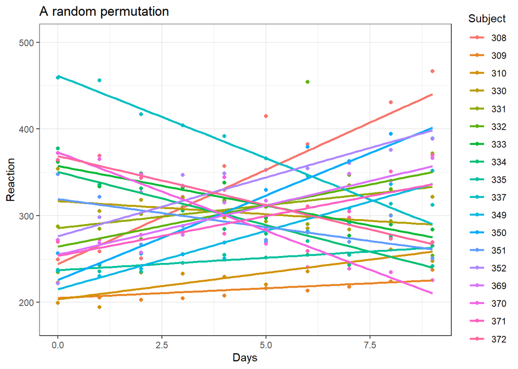

```r
library(ggplot2)
perm=sleepstudy

rnd=sapply((0:17)*10,function(strt) {
  if(rbinom(1,1,.5)==1)
    strt+(1:10) else
      strt+(10:1)
  })
rnd=as.vector(rnd)
perm$Reaction=sleepstudy$Reaction[rnd]

p=ggplot(perm, aes(x = Days, y = Reaction, colour = Subject, group = Subject)) + geom_point()  +geom_smooth(method = lm,alpha=.00)
p + ggtitle("A random permutation") + theme_bw()
```

```r
dati1levperm=perm %>%
  group_by(Subject) %>%
  reframe(estim=(coefficients(lm(Reaction ~ Days))))
dati1levperm$coeff=(rep(c("Interc","Slope"),nlevels(sleepstudy$Subject)))
dati1levperm=spread(dati1levperm, key = coeff, value = estim)

head(dati1levperm)
```

```
## # A tibble: 6 × 3
##   Subject Interc Slope
##   <fct>    <dbl> <dbl>
## 1 308       244. 21.8
## 2 309       205.  2.26
## 3 310       203.  6.11
## 4 330       317. -3.01
## 5 331       286.  5.27
## 6 332       264.  9.57
```

```r
mean(dati1levperm$Slope)
```

```
## [1] 1.985517
```

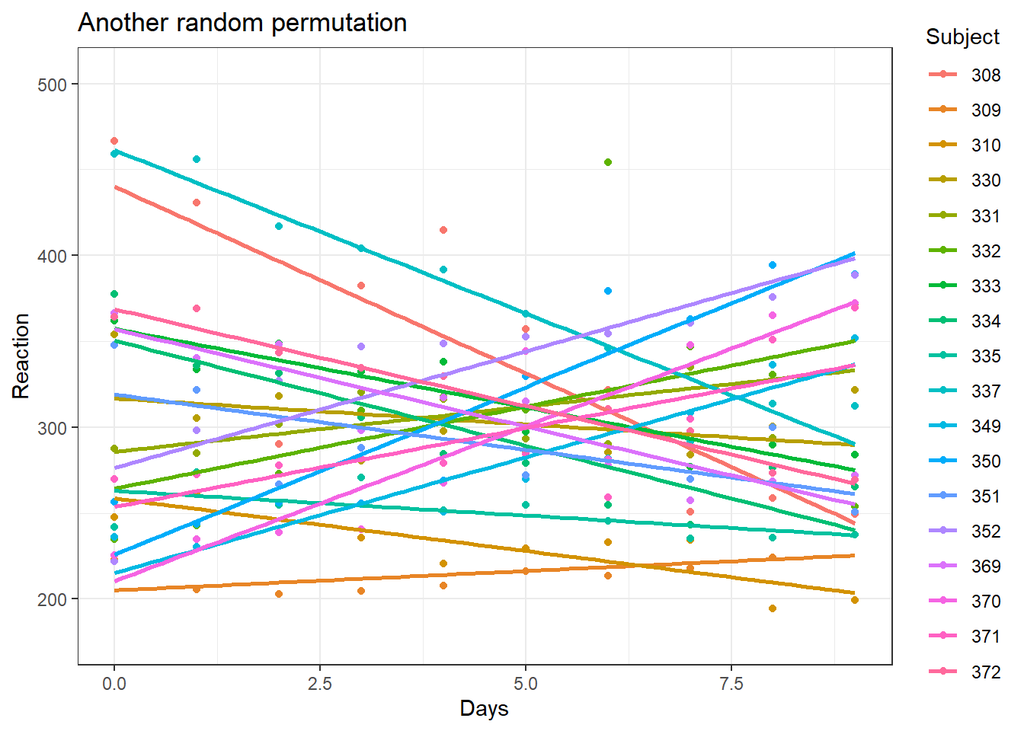

```r
rnd=sapply((0:17)*10,function(strt) {
  if(rbinom(1,1,.5)==1)
    strt+(1:10) else
      strt+(10:1)
  })
rnd=as.vector(rnd)
perm$Reaction=sleepstudy$Reaction[rnd]

p=ggplot(perm, aes(x = Days, y = Reaction, colour = Subject, group = Subject)) + geom_point()  +geom_smooth(method = lm,alpha=.00)
p + ggtitle("Another random permutation") + theme_bw()
```

```r
dati1levperm=perm %>%
  group_by(Subject) %>%
  summarize(estim=(coefficients(lm(Reaction ~ Days))))
dati1levperm$coeff=(rep(c("Interc","Slope"),nlevels(sleepstudy$Subject)))
dati1levperm=spread(dati1levperm, key = coeff, value = estim)

head(dati1levperm)
```

```
## # A tibble: 6 × 3
## # Groups:   Subject [6]
##   Subject Interc  Slope
##   <fct>    <dbl>  <dbl>
## 1 308       440. -21.8
## 2 309       205.   2.26
## 3 310       259.  -6.11
## 4 330       317.  -3.01
## 5 331       286.   5.27
## 6 332       264.   9.57
```

```r
mean(dati1levperm$Slope)
```

```
## [1] -0.6869934
```

```r
Slopes_flips=replicate(100,{
  rnd=sapply((0:17)*10,function(strt) {
  if(rbinom(1,1,.5)==1)
    strt+(1:10) else
      strt+(10:1)
  })
rnd=as.vector(rnd)
perm$Reaction=sleepstudy$Reaction[rnd]
  dati1levperm=perm %>%
  group_by(Subject) %>%
  summarize(Slope=(coefficients(lm(Reaction ~ Days))[2]))
mean(dati1levperm$Slope)
})


# ON OBSERVED DATA:
  dati1lev=sleepstudy %>%
  group_by(Subject) %>%
  summarize(Slope=(coefficients(lm(Reaction ~ Days))[2]))
(Observed=mean(dati1lev$Slope))
```

```
## [1] 10.46729
```

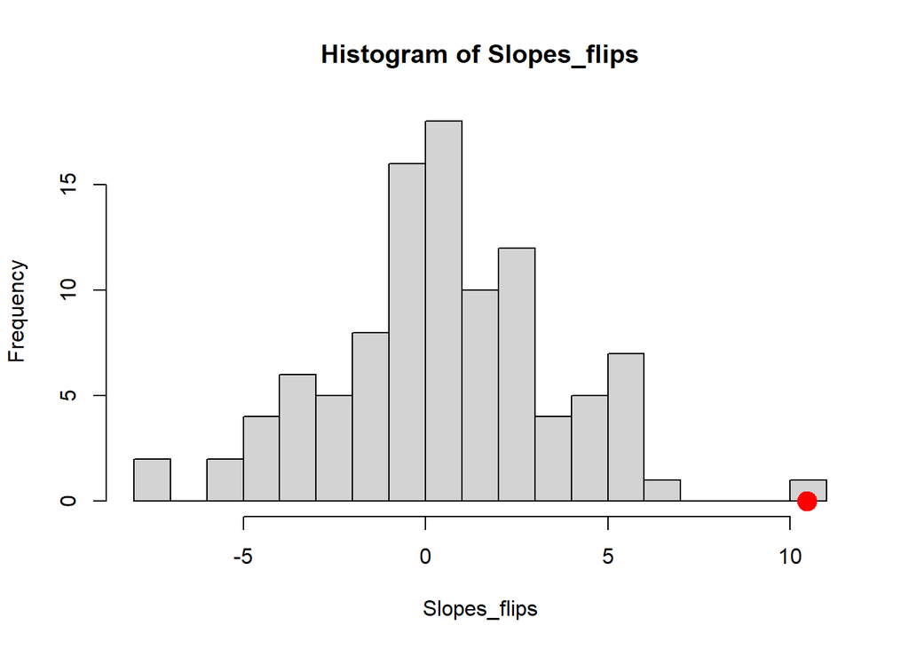

```r
# ALWAYS ADD THE OBSERVED TEST STATISTIC!!! (it is one of the possible permutations)
Slopes_flips=c(Observed,Slopes_flips)

hist(Slopes_flips,20)
points(Observed,0,cex=3,col="red",pch=20)
```

Computing the p-value:

```r
# One sided alternative
mean(Slopes_flips>=Observed)
```

```
## [1] 0.00990099
```

```r
# Two sided alternative
mean(abs(Slopes_flips)>=abs(Observed))
```

```
## [1] 0.00990099
```

```r
#devtools::install_github("livioivil/flipscores")
library(flipscores)
#effect of Days:
(res=flipscores(Slope~1,data=dati1lev))
```

```
## Flip Score Test:
##          score_type = standardized , n_flips =
## Call: flipscores(formula = Slope ~ 1, data = dati1lev)
##
## Coefficients:
## (Intercept)
##    10.46729
```

```r
summary(res)
```

```
##
## Call:
## flipscores(formula = Slope ~ 1, data = dati1lev)
##
## Coefficients:
##             Estimate   Score Std. Error z value Part. Cor Pr(>|z|)
## (Intercept)   10.467 188.411     51.994   3.624     188.4    2e-04 ***
## ---
## Signif. codes:  0 '***' 0.001 '**' 0.01 '*' 0.05 '.' 0.1 ' ' 1
##
## (Dispersion parameter for gaussian family taken to be 43.01034)
##
##     Null deviance: 731.18  on 17  degrees of freedom
## Residual deviance: 731.18  on 17  degrees of freedom
## AIC: 121.76
##
## Number of Fisher Scoring iterations: 2
```

# Detour

Let’s work on Time 0 and 1 only, one can perform paired t-test

```r
sleepstudy2=sleepstudy[sleepstudy$Days<=1,]

t.test(sleepstudy2$Reaction[sleepstudy2$Days==1]-sleepstudy2$Reaction[sleepstudy2$Days==0])
```

```
##
##  One Sample t-test
##
## data:  sleepstudy2$Reaction[sleepstudy2$Days == 1] - sleepstudy2$Reaction[sleepstudy2$Days == 0]
## t = 1.3972, df = 17, p-value = 0.1803
## alternative hypothesis: true mean is not equal to 0
## 95 percent confidence interval:
##  -4.000254 19.688154
## sample estimates:
## mean of x
##   7.84395
```

or linear model:

```r
sleepstudy2$Subject=factor(sleepstudy2$Subject)
mod <- lm(Reaction ~ Days+ Subject, sleepstudy2)
summary(mod)
```

```
##
## Call:
## lm(formula = Reaction ~ Days + Subject, data = sleepstudy2)
##
## Residuals:
##     Min      1Q  Median      3Q     Max
## -34.336  -5.336   0.000   5.336  34.336
##
## Coefficients:
##             Estimate Std. Error t value Pr(>|t|)
## (Intercept)  250.210     12.235  20.450 2.08e-13 ***
## Days           7.844      5.614   1.397  0.18031
## Subject309   -40.132     16.842  -2.383  0.02911 *
## Subject310   -57.439     16.842  -3.411  0.00333 **
## Subject330    56.839     16.842   3.375  0.00360 **
## Subject331    32.172     16.842   1.910  0.07312 .
## Subject332   -15.296     16.842  -0.908  0.37645
## Subject333    32.566     16.842   1.934  0.06998 .
## Subject334    16.705     16.842   0.992  0.33517
## Subject335     3.645     16.842   0.216  0.83121
## Subject337    58.954     16.842   3.500  0.00274 **
## Subject349   -20.922     16.842  -1.242  0.23099
## Subject350    -4.257     16.842  -0.253  0.80349
## Subject351    21.160     16.842   1.256  0.22596
## Subject352     5.803     16.842   0.345  0.73464
## Subject369    16.048     16.842   0.953  0.35401
## Subject370   -24.239     16.842  -1.439  0.16825
## Subject371    17.029     16.842   1.011  0.32612
## Subject372    17.311     16.842   1.028  0.31843
## ---
## Signif. codes:  0 '***' 0.001 '**' 0.01 '*' 0.05 '.' 0.1 ' ' 1
##
## Residual standard error: 16.84 on 17 degrees of freedom
## Multiple R-squared:   0.87,  Adjusted R-squared:  0.7324
## F-statistic: 6.323 on 18 and 17 DF,  p-value: 0.0001954
```

or Repeated Measures:

```r
mod=aov(Reaction ~ Days + Error(Subject/(Days)),data=sleepstudy)
summary(mod)
```

```
##
## Error: Subject
##           Df Sum Sq Mean Sq F value Pr(>F)
## Residuals 17 250618   14742
##
## Error: Subject:Days
##           Df Sum Sq Mean Sq F value   Pr(>F)
## Days       1 162703  162703   45.85 3.26e-06 ***
## Residuals 17  60322    3548
## ---
## Signif. codes:  0 '***' 0.001 '**' 0.01 '*' 0.05 '.' 0.1 ' ' 1
##
## Error: Within
##            Df Sum Sq Mean Sq F value Pr(>F)
## Residuals 144  94312   654.9
```

or Mixed model (note that we can’t set a random slope when we have only two observations; the random coefficients would be not separable from the random error):

```r
library(lmerTest)
mod <- lmer(Reaction ~ 1+Days + (1 | Subject), data=sleepstudy2)
summary(mod)
```

```
## Linear mixed model fit by REML. t-tests use Satterthwaite's method [
## lmerModLmerTest]
## Formula: Reaction ~ 1 + Days + (1 | Subject)
##    Data: sleepstudy2
##
## REML criterion at convergence: 326.3
##
## Scaled residuals:
##      Min       1Q   Median       3Q      Max
## -2.04455 -0.26699 -0.01685  0.30707  2.03303
##
## Random effects:
##  Groups   Name        Variance Std.Dev.
##  Subject  (Intercept) 791.3    28.13
##  Residual             283.6    16.84
## Number of obs: 36, groups:  Subject, 18
##
## Fixed effects:
##             Estimate Std. Error      df t value Pr(>|t|)
## (Intercept)  256.652      7.728  22.051  33.211   <2e-16 ***
## Days           7.844      5.614  17.000   1.397     0.18
## ---
## Signif. codes:  0 '***' 0.001 '**' 0.01 '*' 0.05 '.' 0.1 ' ' 1
##
## Correlation of Fixed Effects:
##      (Intr)
## Days -0.363
```

# (minimal) Bibliography

lme4 package https://cran.r-project.org/web/packages/lme4/vignettes/lmer.pdf

Jonathan Baron (2011) Notes on the use of R for psychology experiments and questionnaires https://www.sas.upenn.edu/~baron/from_cattell/rpsych/rpsych.html

Pinheiro, J., & Bates, D. (2006) Mixed-effects models in S and S-PLUS. https://www.springer.com/gp/book/9780387954580

Bates, D. (2022) lme4: Mixed-effects modeling with R. https://stat.ethz.ch/~maechler/MEMo-pages/lMMwR.pdf

Fox, J. (2015) Applied regression analysis and generalized linear models. https://us.sagepub.com/en-us/nam/applied-regression-analysis-and-generalized-linear-models/book246125

Fox, J., & Weisberg, S. (2018) An R companion to applied regression. https://us.sagepub.com/en-us/nam/an-r-companion-to-applied-regression/book246125

Bliese, P. (2022) Multilevel modeling in R (2.7). https://cran.r-project.org/doc/contrib/Bliese_Multilevel.pdf

Baayen, R. H., Davidson, D. J., & Bates, D. M. (2008) Mixed-effects modeling with crossed random effects for subjects and items. https://doi.org/10.1016/j.jml.2007.12.005

Bürkner, P. C. (2017) brms: An R package for Bayesian multilevel models using Stan. https://doi.org/10.18637/jss.v080.i01

McElreath, R. (2020) Statistical rethinking: A Bayesian course with examples in R and Stan. https://xcelab.net/rm/statistical-rethinking/

GLMM FAQ by Ben Bolker and others https://bbolker.github.io/mixedmodels-misc/glmmFAQ.html

A complete course on mixed models (in italian) https://osf.io/b7tkp/